# PART I - (FORD GOBIKE DATASET EXPLORATION)

## By Frank Emmanuel Azibolanari

# INTRODUCTION

This data set includes information about individual rides made in a bike-sharing system covering the greater San Francisco Bay area. I'll be exploring this dataset using visualisations to gain insights from the data.

## PRELIMINARY WRANGLIING

```python
#Importing all the neccessary modules
import pandas as pd
import numpy as np
import matplotlib.pyplot as plt
import seaborn as sns
%matplotlib inline

import warnings
warnings.simplefilter(action='ignore', category=FutureWarning)
```

```python
#Loading the dataset into pandas Dataframe
original_df = pd.read_csv("201902-fordgobike-tripdata.csv")
```

```python
#Taking a peek into the data
original_df.head()
```

|  | duration_sec | start_time | end_time | start_station_id | start_station_name | start_station_latitude | start_station_longitude | end_station_id | end_station_name | end_station_latitude | end_station_longitude | bike_id | user_type | member_birth_year | member_gender | bike_share_for_all_trip |
| --- | --- | --- | --- | --- | --- | --- | --- | --- | --- | --- | --- | --- | --- | --- | --- | --- |
| 0 | 52185 | 2019-02-28 17:32:10.1450 | 2019-03-01 08:01:55.9750 | 21.0 | Montgomery St BART Station (Market St at 2nd St) | 37.789625 | -122.400811 | 13.0 | Commercial St at Montgomery St | 37.794231 | -122.402923 | 4902 | Customer | 1984.0 | Male | No |
| 1 | 42521 | 2019-02-28 18:53:21.7890 | 2019-03-01 06:42:03.0560 | 23.0 | The Embarcadero at Steuart St | 37.791464 | -122.391034 | 81.0 | Berry St at 4th St | 37.775880 | -122.393170 | 2535 | Customer | NaN | NaN | No |
| 2 | 61854 | 2019-02-28 12:13:13.2180 | 2019-03-01 05:24:08.1460 | 86.0 | Market St at Dolores St | 37.769305 | -122.426826 | 3.0 | Powell St BART Station (Market St at 4th St) | 37.786375 | -122.404904 | 5905 | Customer | 1972.0 | Male | No |
| 3 | 36490 | 2019-02-28 17:54:26.0100 | 2019-03-01 04:02:36.8420 | 375.0 | Grove St at Masonic Ave | 37.774836 | -122.446546 | 70.0 | Central Ave at Fell St | 37.773311 | -122.444293 | 6638 | Subscriber | 1989.0 | Other | No |
| 4 | 1585 | 2019-02-28 23:54:18.5490 | 2019-03-01 00:20:44.0740 | 7.0 | Frank H Ogawa Plaza | 37.804562 | -122.271738 | 222.0 | 10th Ave at E 15th St | 37.792714 | -122.248780 | 4898 | Subscriber | 1974.0 | Male | Yes |

```python
# Checking the information about the structure of the data
original_df.info()
```

```
<class 'pandas.core.frame.DataFrame'>
RangeIndex: 183412 entries, 0 to 183411
Data columns (total 16 columns):
 #   Column                   Non-Null Count   Dtype
---  ------                   --------------   -----
 0   duration_sec             183412 non-null  int64
 1   start_time               183412 non-null  object
 2   end_time                 183412 non-null  object
 3   start_station_id         183215 non-null  float64
 4   start_station_name       183215 non-null  object
 5   start_station_latitude   183412 non-null  float64
 6   start_station_longitude  183412 non-null  float64
 7   end_station_id           183215 non-null  float64
 8   end_station_name         183215 non-null  object
 9   end_station_latitude     183412 non-null  float64
 10  end_station_longitude    183412 non-null  float64
 11  bike_id                  183412 non-null  int64
 12  user_type                183412 non-null  object
 13  member_birth_year        175147 non-null  float64
 14  member_gender            175147 non-null  object
 15  bike_share_for_all_trip  183412 non-null  object
dtypes: float64(7), int64(2), object(7)
memory usage: 22.4+ MB
```

##### Let's change the columns to appropriate datatypes.

```python
# Changing the start and end times from string to datetime format
original_df.start_time = pd.to_datetime(original_df.start_time)
original_df.end_time = pd.to_datetime(original_df.end_time)

original_df.member_birth_year = pd.to_datetime(original_df.member_birth_year, format = '%Y')
```

##### Let's Change The Id columns from floats/int to Objects

```python
original_df['start_station_id'] = original_df['start_station_id'].astype(str)
original_df['end_station_id'] = original_df['end_station_id'].astype(str)
original_df['bike_id'] = original_df['bike_id'].astype(str)
```

##### Let's Change The Member's gender and user type columns to Categorical Datatypes.

```python
original_df.member_gender = original_df.member_gender.astype('category')
original_df.user_type = original_df.user_type.astype('category')
```

##### Let's Confirm if the Changes have been made

```python
original_df.info()
```

```
<class 'pandas.core.frame.DataFrame'>
RangeIndex: 183412 entries, 0 to 183411
Data columns (total 16 columns):
 #   Column                   Non-Null Count   Dtype
---  ------                   --------------   -----
 0   duration_sec             183412 non-null  int64
 1   start_time               183412 non-null  datetime64[ns]
 2   end_time                 183412 non-null  datetime64[ns]
 3   start_station_id         183412 non-null  object
 4   start_station_name       183215 non-null  object
 5   start_station_latitude   183412 non-null  float64
 6   start_station_longitude  183412 non-null  float64
 7   end_station_id           183412 non-null  object
 8   end_station_name         183215 non-null  object
 9   end_station_latitude     183412 non-null  float64
 10  end_station_longitude    183412 non-null  float64
 11  bike_id                  183412 non-null  object
 12  user_type                183412 non-null  category
 13  member_birth_year        175147 non-null  datetime64[ns]
 14  member_gender            175147 non-null  category
 15  bike_share_for_all_trip  183412 non-null  object
dtypes: category(2), datetime64[ns](3), float64(4), int64(1), object(6)
memory usage: 19.9+ MB
```

As we can see the changes have been applied to the dataframe. we can see the 'start_time', 'end_time', amd 'member_birth_year' columns have been changed to datetime format. The 'start_station-id', 'end_station_id', and 'bike_id' columns have been changed to objects.The 'member_gender' and 'user type' columns has been changed to categorical.

#### Creating New Columns for Month, Day and Hour From the Start_time column

```python
# Creating the months column
original_df['start_month']= original_df['start_time'].dt.month_name()

# Creating day name Column
weekdays = ['Monday','Tuesday', 'Wednesday', 'Thursday', 'Friday', 'Saturday', 'Sunday']
original_df['start_day'] = pd.Categorical(original_df.start_time.dt.strftime('%A'), categories=weekdays, ordered=True)

# Creating the Hour column in 12 Hour Format
am_pm = ['12 AM', '01 AM', '02 AM', '03 AM', '04 AM', '05 AM', '06 AM', '07 AM', '08 AM', '09 AM', '10 AM', '11 AM', '12 PM', '01 PM', '02 PM', '03 PM', '04 PM', '05 PM', '06 PM', '07 PM', '08 PM', '09 PM', '10 PM', '11 PM']
original_df['start_hour'] = pd.Categorical(original_df.start_time.dt.strftime('%I %p'), categories=am_pm, ordered=True)
```

```python
# Confirming Changes
original_df.head()
```

|  | duration_sec | start_time | end_time | start_station_id | start_station_name | start_station_latitude | start_station_longitude | end_station_id | end_station_name | end_station_latitude | end_station_longitude | bike_id | user_type | member_birth_year | member_gender | bike_share_for_all_trip | start_month | start_day | start_hour |
| --- | --- | --- | --- | --- | --- | --- | --- | --- | --- | --- | --- | --- | --- | --- | --- | --- | --- | --- | --- |
| 0 | 52185 | 2019-02-28 17:32:10.145 | 2019-03-01 08:01:55.975 | 21.0 | Montgomery St BART Station (Market St at 2nd St) | 37.789625 | -122.400811 | 13.0 | Commercial St at Montgomery St | 37.794231 | -122.402923 | 4902 | Customer | 1984-01-01 | Male | No | February | Thursday | 05 PM |
| 1 | 42521 | 2019-02-28 18:53:21.789 | 2019-03-01 06:42:03.056 | 23.0 | The Embarcadero at Steuart St | 37.791464 | -122.391034 | 81.0 | Berry St at 4th St | 37.775880 | -122.393170 | 2535 | Customer | NaT | NaN | No | February | Thursday | 06 PM |
| 2 | 61854 | 2019-02-28 12:13:13.218 | 2019-03-01 05:24:08.146 | 86.0 | Market St at Dolores St | 37.769305 | -122.426826 | 3.0 | Powell St BART Station (Market St at 4th St) | 37.786375 | -122.404904 | 5905 | Customer | 1972-01-01 | Male | No | February | Thursday | 12 PM |
| 3 | 36490 | 2019-02-28 17:54:26.010 | 2019-03-01 04:02:36.842 | 375.0 | Grove St at Masonic Ave | 37.774836 | -122.446546 | 70.0 | Central Ave at Fell St | 37.773311 | -122.444293 | 6638 | Subscriber | 1989-01-01 | Other | No | February | Thursday | 05 PM |
| 4 | 1585 | 2019-02-28 23:54:18.549 | 2019-03-01 00:20:44.074 | 7.0 | Frank H Ogawa Plaza | 37.804562 | -122.271738 | 222.0 | 10th Ave at E 15th St | 37.792714 | -122.248780 | 4898 | Subscriber | 1974-01-01 | Male | Yes | February | Thursday | 11 PM |

```python
#  COPYING CLEANED DATAFRAME
df = original_df.copy()
# Saving Cleaned CSV file
df.to_csv("cleaned_201902-fordgobike-tripdata.csv", index=False)
```

## What is the structure of your dataset?

> The Ford GoBike System data consists of 183412 rows with a total of 16 columns. In other words, there are 183412 records and 16 variables. By using 'df.info' we can see the number of rows and columns, as well as the datatypes in the dataset. I noticed the data only covers report for just the month of febuary 2019 mostly, with some end times stretching to march.

## What is/are the main feature(s) of interest in your dataset?

> The main features of interest in this dataset is duration_sec, start_time.

## What features in the dataset do you think will help support your investigation into your feature(s) of interest?

> To help us gain much understanding about the rides features such as user type, member birth year and gender I created a few new columns "month", "Day", "hour" by extracting it from 'Start_time' for the purpose of further analysis.

# Univariate Exploration

```python
df.describe()
```

|  | duration_sec | start_station_latitude | start_station_longitude | end_station_latitude | end_station_longitude |
| --- | --- | --- | --- | --- | --- |
| count | 183412.000000 | 183412.000000 | 183412.000000 | 183412.000000 | 183412.000000 |
| mean | 726.078435 | 37.771223 | -122.352664 | 37.771427 | -122.352250 |
| std | 1794.389780 | 0.099581 | 0.117097 | 0.099490 | 0.116673 |
| min | 61.000000 | 37.317298 | -122.453704 | 37.317298 | -122.453704 |
| 25% | 325.000000 | 37.770083 | -122.412408 | 37.770407 | -122.411726 |
| 50% | 514.000000 | 37.780760 | -122.398285 | 37.781010 | -122.398279 |
| 75% | 796.000000 | 37.797280 | -122.286533 | 37.797320 | -122.288045 |
| max | 85444.000000 | 37.880222 | -121.874119 | 37.880222 | -121.874119 |

### Trip Duration Distribution

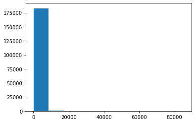

```python
# Ploting a histogram to show duration distribution
plt.hist(data=df, x = 'duration_sec');
```

Unfortunately, we were not able to gain much insight from this plot. Alternatively, we can plot this histogram using the logarithmic scale, so we can further inspect the distribution.

```python
# checking the log stats of the duration_sec column
np.log10(df['duration_sec'].describe())
```

```
count    5.263428
mean     2.860984
std      3.253917
min      1.785330
25%      2.511883
50%      2.710963
75%      2.900913
max      4.931682
Name: duration_sec, dtype: float64
```

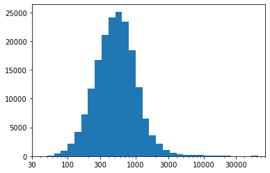

```python
## Ploting the Chart Using Logarithmic Scale
bin10 =  10 ** np.arange(1.7, 5+0.1,0.1)
ticks = [0.1, 0.3, 1, 3, 10, 30, 100, 300, 1000, 3000, 10000, 30000, 100000]
labels = ['{}'.format(v) for v in ticks]
plt.hist(data=df, x = 'duration_sec', bins = bin10)
plt.xscale('log')
plt.xticks(ticks, labels)
plt.xlim(30,80000);
```

Now we can see in more details the distribution of the duration time. we observed that the log plot is symentrical and unimodal, and most of the distribution of the duration falls somewhere within 60 to 10,000 seconds, but we can see some outliers past 10,000 upto 30,000 and beyond. Because this plot is symentrical and unimodal, the mean is located at the centre of the distribution... Looking a the plot, the mean is somewhere around 700 secs.

### User Type Frequency

```python
total_users = df.user_type.value_counts()#.sum()
total_users
```

```
Subscriber    163544
Customer       19868
Name: user_type, dtype: int64
```

```python
# Creating Function to plot Seaborn's Count plot
def sns_countplot(x_col, order_col):
    countplot = sns.countplot(x= x_col, data=df, order = df[order_col].value_counts().index)
    return countplot
```

```python
# Creating a function to plot matplotlib Pie Charts
def plt_pie(col_name):
    v_count = df[col_name].value_counts()
    piechart = plt.pie(v_count, labels = v_count.index, startangle = 90, autopct='%1.2f%%')
    return piechart
```

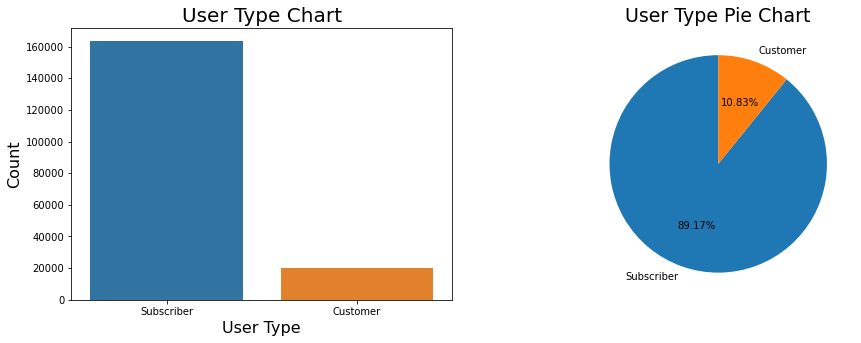

```python
fig = plt.figure()
fig.set_figheight(5)
fig.set_figwidth(15)


plt.subplot(1,2,1)
sns_countplot("user_type", "user_type")
plt.xlabel('User Type', fontsize=16)
plt.ylabel('Count', fontsize=16)
plt.title("User Type Chart", fontsize=20)

plt.subplot(1,2,2)
plt_pie('user_type')
plt.title("User Type Pie Chart", fontsize =19 );
```

We can see there is a huge disparity between the nummbers of the Subscribers against Customers. There are a total of 183412 Users in the dataset The Customers makes only about 10.83%, and the Subscribers are the majority with over 89.17%.

### Gender Frequency

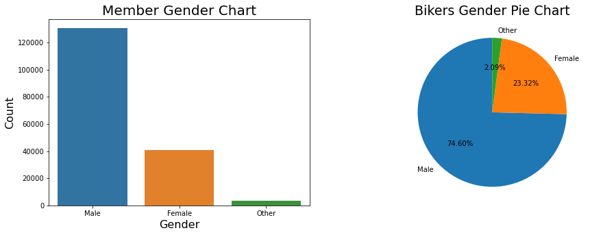

```python
fig = plt.figure()
fig.set_figheight(5)
fig.set_figwidth(15)

plt.subplot(1,2,1)
sns_countplot("member_gender", "member_gender")
plt.xlabel('Gender', fontsize=16)
plt.ylabel('Count', fontsize=16)
plt.title("Member Gender Chart", fontsize=20)

plt.subplot(1,2,2)
plt_pie('member_gender')
plt.title("Bikers Gender Pie Chart", fontsize =19 );
```

We can see that majority of the riders are Men, followed by women and other gender. Again we see a huge disparity here, The majority of riders are men taking about 74.60%, women in the second place with just 23.32%, the other genders even lesser with just 2.09%.

## Bike Share Options

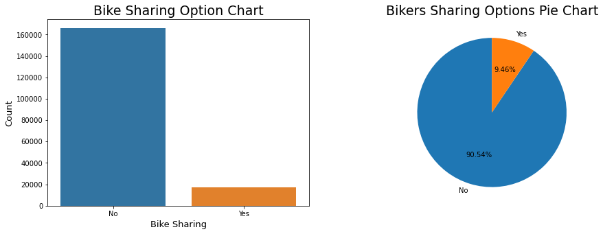

```python
fig = plt.figure()
fig.set_figheight(5)
fig.set_figwidth(15)

plt.subplot(1,2,1)
sns_countplot('bike_share_for_all_trip','bike_share_for_all_trip')
plt.title('Bike Sharing Option Chart', fontsize=19)
plt.xlabel('Bike Sharing', fontsize=13)
plt.ylabel('Count', fontsize=13);

plt.subplot(1,2,2)
plt_pie('bike_share_for_all_trip')
plt.title("Bikers Sharing Options Pie Chart", fontsize =19 );
```

Most of the riders did not share bikes during their trips. we can see that only 9.46% chose to share bike.

### What of day of the week are trips taken the most?

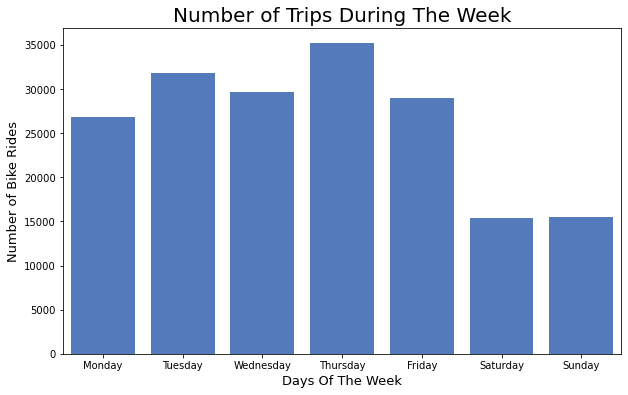

```python
days = ['Monday', 'Tuesday', 'Wednesday', 'Thursday', 'Friday', 'Saturday', 'Sunday']
plt.figure(figsize=(10,6))
plt.title('Number of Trips During The Week', fontsize=20)
sns.countplot(data=df, x='start_day', order=days, color='#4375cc')
plt.xlabel('Days Of The Week', fontsize=13)
plt.ylabel('Number of Bike Rides', fontsize=13);
```

We notice there are lesser number of trips taken on the weekends, Saturdays and Sundays. And the days with highest number of trips taken are Thursday, Tuesday and Wednesday, Friday, and Monday respectively.

### What time of the day are trips taken the most?

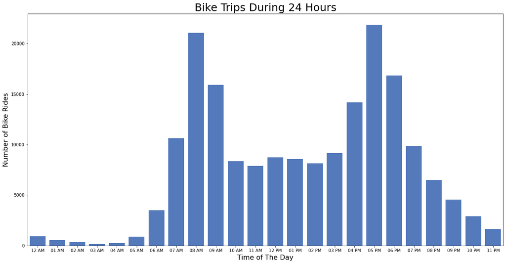

```python
plt.figure(figsize=(20,10))
plt.title('Bike Trips During 24 Hours', fontsize=25)
sns.countplot(data=df, x='start_hour', color='#4375cc')
plt.xlabel('Time of The Day', fontsize=16)
plt.ylabel('Number of Bike Rides', fontsize=16);
```

In the plot we see when the bike bikers started their trips during the day. We observed lower activity during the early hours of the day, i.e from 12am to 5am. At 6am, we start to notice more people have started their trip, the growth in number increases rapidly to a peak at 8am, then declines at 9am, stays fairly stable throughout the afternoon, and during the evening around 4pm, we start to obeserve inscrease in the number of rides, that rapidly reaches the peak of the day at 5pm, then consistently declines towards the end of the day at night.

## Bike Stations

> There are 329 Bike stations in this dataset.

```python
print(df.start_station_name.nunique())
print(df.end_station_name.nunique())
```

```
329
329
```

### Which Stations are the most Busiest? (Top 20 busiest Staions)

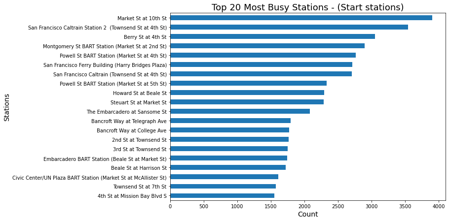

```python
startstations_topbusy =df.start_station_name.value_counts().nlargest(20)
plt.figure(figsize=(10,7))
startstations_topbusy.sort_values(ascending=True).plot.barh()
plt.xlabel('Count', fontsize=14)
plt.ylabel('Stations', fontsize=14)
plt.title('Top 20 Most Busy Stations - (Start stations)', fontsize=18)
```

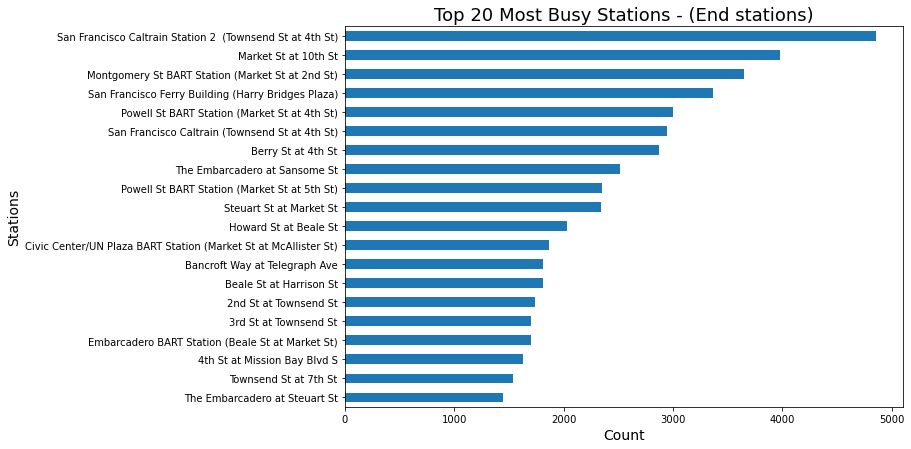

```python
endstations_topbusy = df.end_station_name.value_counts().nlargest(20)
plt.figure(figsize=(10,7))
endstations_topbusy.sort_values(ascending=True).plot.barh()
plt.xlabel('Count', fontsize=14)
plt.ylabel('Stations', fontsize=14)
plt.title('Top 20 Most Busy Stations - (End stations)', fontsize=18)
```

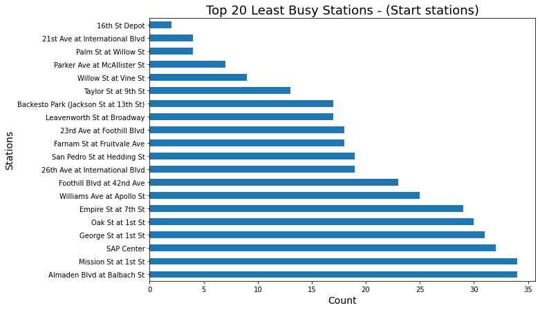

```python
startstations_leastbusy =df.start_station_name.value_counts().nsmallest(20)
plt.figure(figsize=(10,7))
startstations_leastbusy.sort_values(ascending=False).plot.barh()
plt.xlabel('Count', fontsize=14)
plt.ylabel('Stations', fontsize=14)
plt.title('Top 20 Least Busy Stations - (Start stations)', fontsize=18)
```

[figure not shown]

```python
endstations_leastbusy = df.end_station_name.value_counts().nsmallest(20)
plt.figure(figsize=(10,7))
endstations_topbusy.sort_values(ascending=False).plot.barh()
plt.xlabel('Count', fontsize=14)
plt.ylabel('Stations', fontsize=14)
plt.title('Top 20 Least Busy Stations - (End stations)', fontsize=18)
```

### AGE DISTRIBUTION

```python
df['member_birth_year'].describe()
```

```
count                  175147
unique                     75
top       1988-01-01 00:00:00
freq                    10236
first     1878-01-01 00:00:00
last      2001-01-01 00:00:00
Name: member_birth_year, dtype: object
```

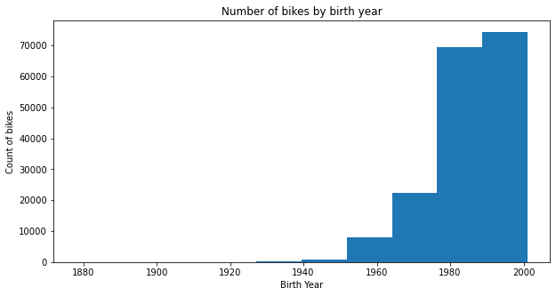

```python
plt.figure(figsize=(10,5))
df['member_birth_year'].hist(bins = 10)
plt.grid(False)
plt.ylabel('Count of bikes')
plt.xlabel('Birth Year')
plt.title('Number of bikes by birth year')
```

### Discuss the distribution(s) of your variable(s) of interest. Were there any unusual points? Did you need to perform any transformations?

> As earlier stated my main features are the duration and start time. I noticed there were a few outliers in the histogram of the duration which means that a few persons finished thier rides in a relatively very long time. For tarnsformation, I had to plot the histogram in logarithmic scale to further inspect the distribution.

> For the start time (during the day), as expected I observed lower number of rides during the night time and very early hours in the morning, we observed the first peak during 8am, this could be due to the the assumption that most people go to school,work etc around 8am, and we also notice the second and highest peak during 5pm, could be the closing time of most institutions or work places, then again these are merely speculations.

### Of the features you investigated, were there any unusual distributions? Did you perform any operations on the data to tidy, adjust, or change the form of the data? If so, why did you do this?

> I changed a couple of columns data types to more appropriate datatypes for my analysis. These include changing the start_time,end_time and member_birth_year columns to datetime format, then changing the bike_id, start_station and end_station to strings, then changing member_gender and user type to categorical datatypes.

> I also created three additional columns by extracting from the start_time column. These includes, the month, the day of the week and the time of the day

## BIVARIATE

```python
# Creating a function to plot a bivariate bar chart, where the first variable is whichever column we choose and the second variable in the mean duration_sec
def avg_dur_based_on(col_name):
    bi_barplot = df.groupby(col_name)['duration_sec'].mean().plot.bar()
    return bi_barplot
```

### What is the average Trip duration based on user type?

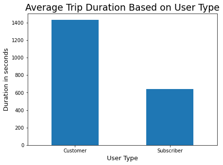

```python
plt.figure(figsize=(7,5))
avg_dur_based_on('user_type')
plt.title('Average Trip Duration Based on User Type', fontsize=19)
plt.ylabel('Duration in seconds', fontsize=13)
plt.xlabel('User Type', fontsize=13)
plt.xticks(rotation=0);
```

We can see the that Customers significantly spend time biking than subscribers generally.

```python
### creating a filter for customers and subscribers
customers=df.user_type=='Customer'
subscribers = df.user_type=='Subscriber'

df.user_type.value_counts()
```

```
Subscriber    163544
Customer       19868
Name: user_type, dtype: int64
```

### What is the average trip duration based on Gender of the riders?

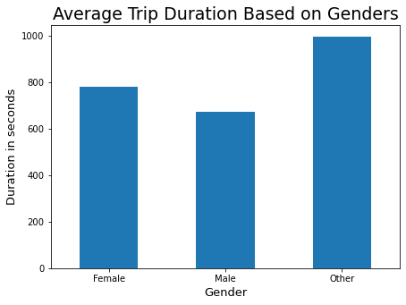

```python
plt.figure(figsize=(7,5))
avg_dur_based_on('member_gender')
plt.title('Average Trip Duration Based on Genders', fontsize=19)
plt.ylabel('Duration in seconds', fontsize=13)
plt.xlabel('Gender', fontsize=13)
plt.xticks(rotation=0);
```

We can see from the bar chart that the other genders have the highest average duration time, followed by females, and the lowest avg duration time is from the males.

### What's the average trip duration based on bike sharing choice?

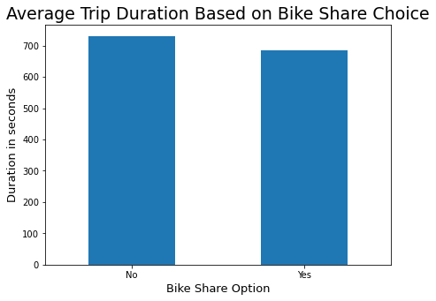

```python
plt.figure(figsize=(7,5))
avg_dur_based_on('bike_share_for_all_trip')
plt.title('Average Trip Duration Based on Bike Share Choice', fontsize=19)
plt.ylabel('Duration in seconds', fontsize=13)
plt.xlabel('Bike Share Option', fontsize=13)
plt.xticks(rotation=0);
```

The average duration of both shared biking duration and not shared are pretty close. Although the average duration of not shared bike trips is a little higher. Regardless, I speculate that its is very likely sharing bike or not doesn't really influence the duration of the trip.

### Does the start time influence the mean duration of rides?

```python
# Creating function to plot bivariate line chart, first variable will be whichever column we choose and the second is the  mean of duration_sec column
def avg_dur_lineplot(col_name):
    time = df.groupby(col_name)['duration_sec'].mean()
    line_plot = sns.lineplot(data=time)
    return line_plot
```

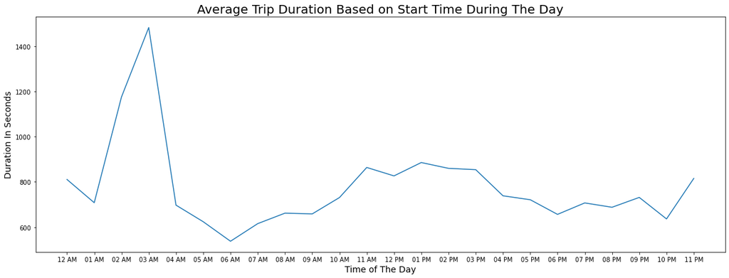

```python
plt.figure(figsize=(20,7))
avg_dur_lineplot('start_hour')
plt.title('Average Trip Duration Based on Start Time During The Day',  fontsize=20)
plt.xlabel('Time of The Day', fontsize=14);
plt.ylabel('Duration In Seconds',  fontsize=14);
```

We can see that in contrast to the number of rides during the day, those who started biking in the early part of the day from 2am to 3am had the highest trip duration probably people who do it for hardcore excercise or training, then the avgerage duration declines drastically from 4am till 6am, then the average duration starts to increase from 7am gradually till 11am and and stay staggering throughout the afternoon, and starts declining by 4pm towards the evening.

### Which days are riders most active based on trip duration?

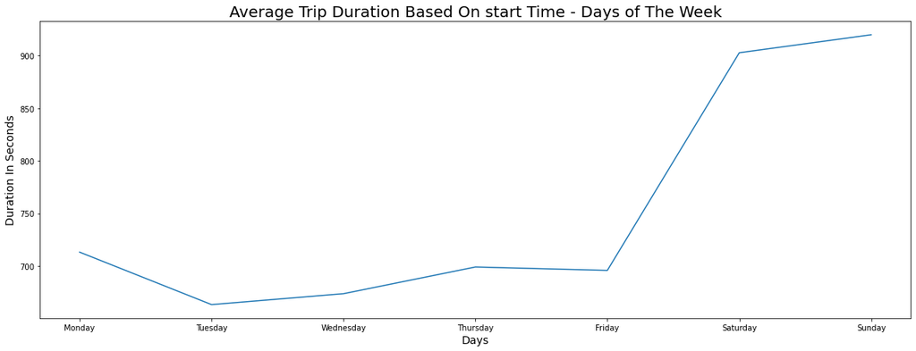

```python
plt.figure(figsize=(20,7))
avg_dur_lineplot('start_day')
plt.title('Average Trip Duration Based On start Time - Days of The Week',  fontsize=20)
plt.xlabel('Days',  fontsize=14)
plt.ylabel('Duration In Seconds',  fontsize=14);
```

Despite the results from the 'Number of Trips During The Week' chart, where most of the rides were carried out during the week, here we can see that trip duration were longer on the weekends and significantly lower on the week days. This makes sense to me, as I imagine a lot of trips during the week are for offical movements such as school, work, etc hence people might be in a hurry to reach their destinations, however during the weekends, I imagine people ride for recreation, excercise, training etc, so they may not be in a rush to get to their distination.

### Does the day of the week does users come out more?

```python
# Creating function to create a bivariate countplot, The first variable 'x' and the second variable 'hue' will be whichever column we choose
def bi_countplot(x_col, hue_col):
    sns_countplot = sns.countplot(data=df, x= x_col , hue= hue_col)
    return sns_countplot
```

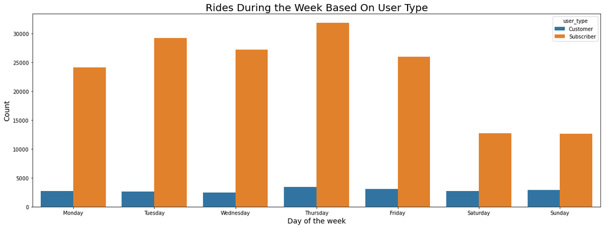

```python
plt.figure(figsize=(20,7))
plt.title('Rides During the Week Based On User Type', fontsize=20)
bi_countplot('start_day','user_type')
plt.xlabel('Day of the week', fontsize =14)
plt.ylabel('Count', fontsize = 14);
```

### What Time of the day does Users active?

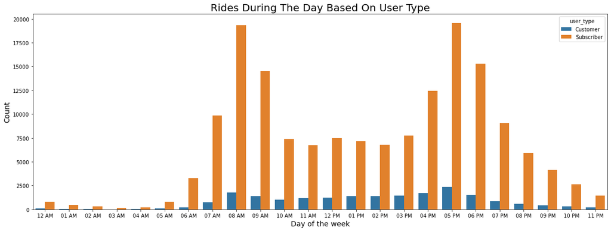

```python
plt.figure(figsize=(20,7))
plt.title('Rides During The Day Based On User Type', fontsize=20)
bi_countplot('start_hour','user_type')
plt.xlabel('Day of the week', fontsize =14)
plt.ylabel('Count', fontsize = 14);
```

There are barely any customers riding in the early hours of the day. It has always been the case that subscribers are the majority so no surprises here, but notice the trend in customers... They are mostly active from 8am to 6pm, this makes me speculate that most of the customers maybe students,workers etc as they there are more rides seen during convention "official working hours"... This is marely a speculation, but I found it interesting.

### What times during the day are riders active based on Gender?

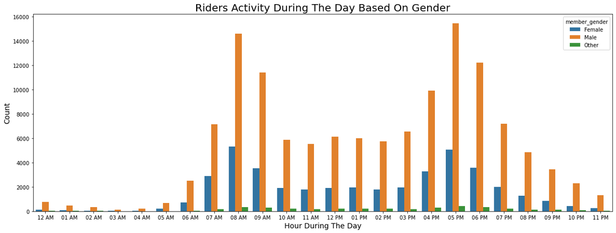

```python
plt.figure(figsize=(20,7))
plt.title('Riders Activity During The Day Based On Gender', fontsize=20)
bi_countplot('start_hour','member_gender')
plt.xlabel('Hour During The Day', fontsize =14)
plt.ylabel('Count', fontsize = 14);
```

During the early hours of the day there are barely any gender riding other than the male, however this changes in the later part of the morning from 6am, we begin to notice a significant amount of females, then by 7am the other genders join in till 9pm, females continue till as a late as 11pm.

### What times during the week are riders active based on Gender?

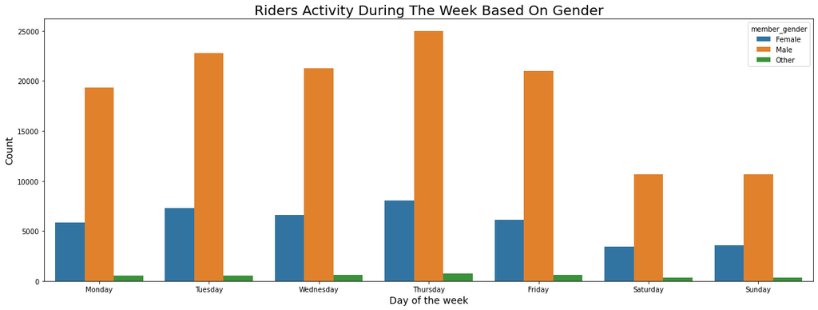

```python
plt.figure(figsize=(20,7))
plt.title('Riders Activity During The Week Based On Gender', fontsize=20)
bi_countplot('start_day','member_gender')
plt.xlabel('Day of the week', fontsize =14)
plt.ylabel('Count', fontsize = 14);
```

There wasn't any interesting pattern here, I did notice that the other genders weren't very active during the weekends.

# MULTIVARIATE

### What is the average trip duration based on user type by gender?

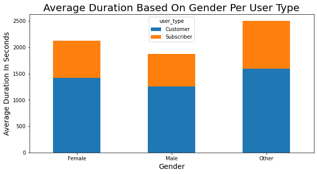

```python
plt.rcParams["figure.figsize"] = (10,5)
avg_usertype_gender = df.groupby(['member_gender','user_type'])['duration_sec'].mean().unstack('user_type')
avg_usertype_gender.plot(kind='bar', stacked=True)
plt.title('Average Duration Based On Gender Per User Type', fontsize=20)
plt.ylabel('Average Duration In Seconds', fontsize=14)
plt.xlabel('Gender', fontsize=14)
plt.xticks(rotation=0);
```

we can see that Here, the 'other' gender class has the highest average duration of rides compared to female and male gender. Across the genders, the subscribers still have the lower average ride duration.

### Based on the question above, what what's the frequency of genders that had trip duration above and below the average trip duration?

```python
above_avg_dur = df[df.duration_sec > df.duration_sec.mean()].reset_index().drop('index', axis=1)
below_avg_dur = df[df.duration_sec < df.duration_sec.mean()].reset_index().drop('index', axis=1)
```

###### Above average

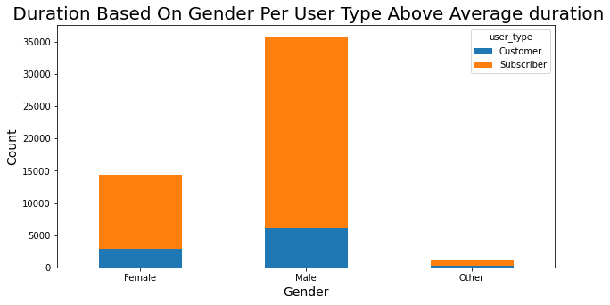

```python
plt.rcParams["figure.figsize"] = (10,5)
top_usertype_gender = above_avg_dur.groupby(['member_gender','user_type'])['duration_sec'].count().unstack('user_type')
top_usertype_gender.plot(kind='bar', stacked=True)
plt.title(' Duration Based On Gender Per User Type Above Average duration', fontsize=20)
plt.ylabel('Count', fontsize=14)
plt.xlabel('Gender', fontsize=14)
plt.xticks(rotation=0);
```

##### Below average

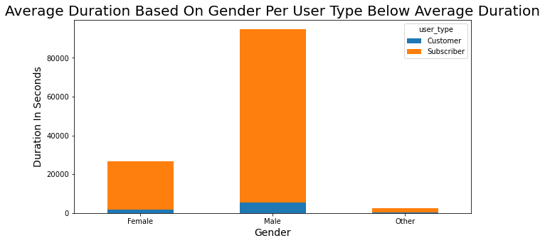

```python
plt.rcParams["figure.figsize"] = (10,5)
blw_usertype_gender = below_avg_dur.groupby(['member_gender','user_type'])['duration_sec'].count().unstack('user_type')
blw_usertype_gender.plot(kind='bar', stacked=True)
plt.title('Average Duration Based On Gender Per User Type Below Average Duration', fontsize=20)
plt.ylabel('Duration In Seconds', fontsize=14)
plt.xlabel('Gender', fontsize=14)
plt.xticks(rotation=0);
```

The result here is quite similar to the one above, however we can notice the significantly lower reprensentation of female customers, and the male customers as well. oddly, there were no count of customers of the 'Other' genders in this chart as well.

# Talk about some of the relationships you observed in this part of the investigation. Were there features that strengthened each other in terms of looking at your feature(s) of interest?

### Were there any interesting or surprising interactions between features?

# Conclusions

> In conclusion, this analyses has been able to show the distributions and frequencies of variables in the dataset. It also showed the splits over genders, start time during the day and during the week, user type as well as bike share options and how these affected the duration of the rides.

> During the course of this project, we've been able to answer several question brained stormed earlier. In summary these are my findings...
- **Bike Sharing and Duration**

  > Despite the disparity in the Number of users that do not share which is larger, and the bikers that shared, the average duration between both groups are very close. Based on this I speculate that bike sharing doesn't strongly influence trip durations.
- **Average Duration Based on User Type**

  > I observed that Subscriber travel throughout the day from morning till night, however the customers tend to travel more during the day especially during work hours... This has lead me to speculate that most of the customers aren't hardcore bikers, probably just bike for regular commute. But with the the limited data, we cannot investigate further.
- **Hours of use Based on Gender**